# Training School BOTTOMS-UP

Marc Ohlmann, Laboratoire d’Écologie Alpine

2022-09-30

# Aim

In this tutorial, we will play with undirected graphical models through two examples:

- A gaussian graphical model using *glasso* and *GLASSOO* packages
- A Poison-lognormal graphical model using *PLNmodels* package

# Gaussian graphical model

- We draw samples in a multivariate normal with sparse precision matrix
- We then infer the precision matrix from the sample covariance matrix

```r
#loading the packages
library(igraph)
library(LaplacesDemon)
library(GGally)
library(glasso)
library(ade4)
library(ggplot2)
library(intergraph)
library(network)
library(reshape2)
library(GLASSOO)
library(PLNmodels)

#setting the seed
set.seed("2022")
```

# Building association network and sampling in multivariate normal distribution

We choose a linear network for the support of the precision matrix (inverse of the covariance matrix).

```r
p <- 6
g <- make_lattice(length = p,dim = 1)
V(g)$name <- LETTERS[1:p]
#g is an object of class 'igraph'
class(g)
```

```
## [1] "igraph"
```

```r
print(g)
```

```
## IGRAPH 3000480 UN-- 6 5 -- Lattice graph
## + attr: name (g/c), dimvector (g/n), nei (g/n), mutual (g/l), circular
## | (g/l), name (v/c)
## + edges from 3000480 (vertex names):
## [1] A--B B--C C--D D--E E--F
```

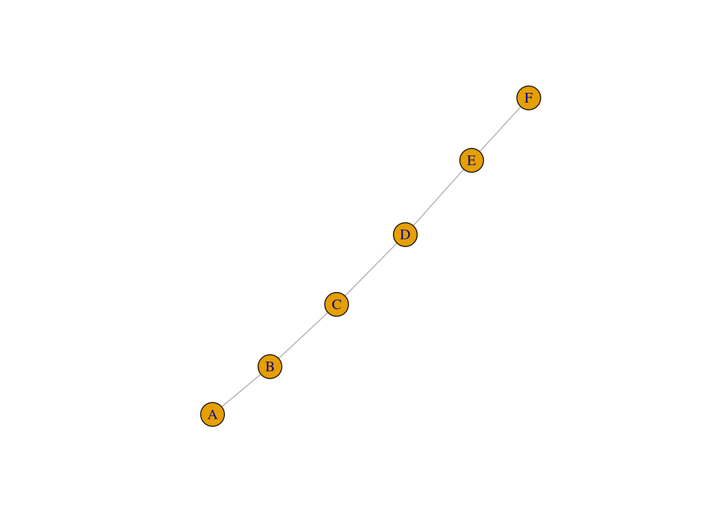

```r
#using igraph plot
plot(g)
```

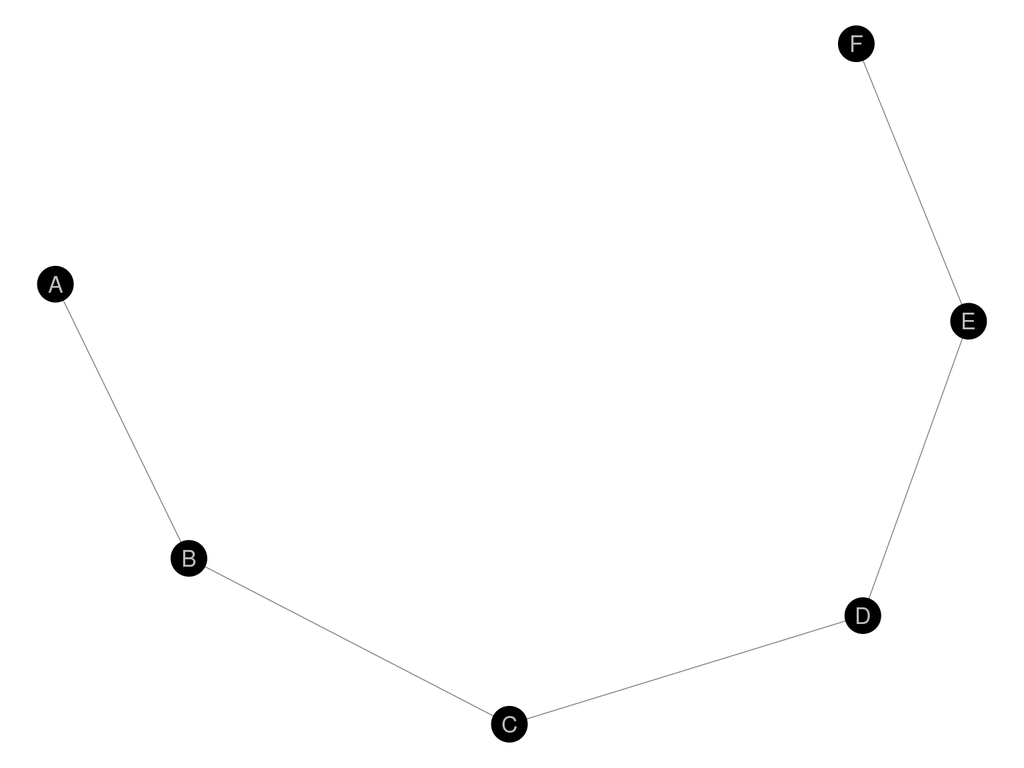

```r
#a nicer representation with ggnet2
ggnet(g,label = TRUE,color = "grey")
```

We add edge weights that are non-zero values of the precision matrix (inverse of the variance-covariance matrix). These are association strengths.

```r
#Adding weights
E(g)$weight <- c(1,1,0.2,1,1)
#Get the adjacency matrix of g
A <- get.adjacency(g,attr = "weight")
#adding variance (diagonal term)
diag(A) = 2
```

**Careful**: Remember that precision matrix coefficients and partial correlation coefficients (the ones of interest for interpretation) are of opposite signs.

```r
A = as.matrix(A)
p_cor_theo <- - A/(sqrt(diag(A) %*% t(diag(A))))
diag(p_cor_theo) = 1
print(A)
```

```
##   A B   C   D E F
## A 2 1 0.0 0.0 0 0
## B 1 2 1.0 0.0 0 0
## C 0 1 2.0 0.2 0 0
## D 0 0 0.2 2.0 1 0
## E 0 0 0.0 1.0 2 1
## F 0 0 0.0 0.0 1 2
```

```r
print(p_cor_theo)
```

```
##      A    B    C    D    E    F
## A  1.0 -0.5  0.0  0.0  0.0  0.0
## B -0.5  1.0 -0.5  0.0  0.0  0.0
## C  0.0 -0.5  1.0 -0.1  0.0  0.0
## D  0.0  0.0 -0.1  1.0 -0.5  0.0
## E  0.0  0.0  0.0 -0.5  1.0 -0.5
## F  0.0  0.0  0.0  0.0 -0.5  1.0
```

We now represent the partial correlation matrix as a network using *ggnet2*

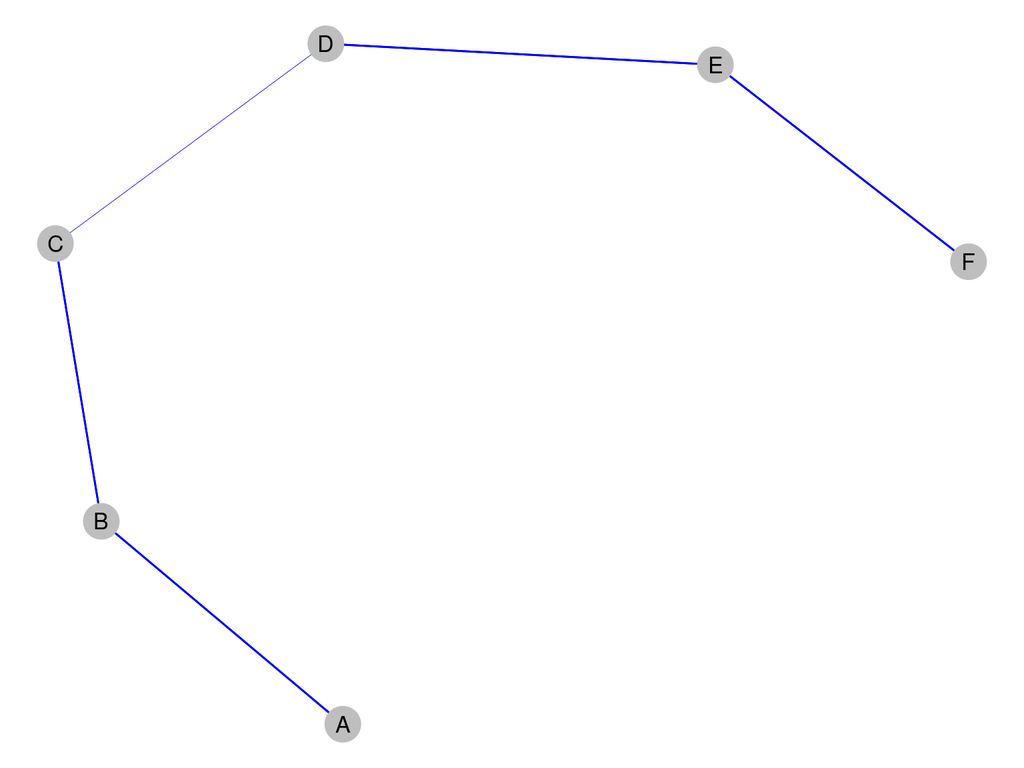

```r
#building igraph objects
g_pcor <- graph_from_adjacency_matrix(abs(p_cor_theo),weighted = TRUE)
# convert it to network format
g_pcor = asNetwork(g_pcor)
ggnet2(g_pcor,label = TRUE,color = "grey",edge.size = "weight",edge.color = "blue")
```

We now draw samples in a multivariate normal distribution of precision matrix A.

```r
#choose mean
mu <- rep(1,p)
X <- rmvnp(n=1000, mu, Omega = as.matrix(A))
```

We now compute the sample correlation matrix

```r
S_cor = cor(X)
print(S_cor)
```

```
##             A           B           C           D           E           F
## A  1.00000000 -0.59186377  0.29186181 -0.01512471  0.03738444 -0.06132183
## B -0.59186377  1.00000000 -0.53195106  0.05881456 -0.06283624  0.08135608
## C  0.29186181 -0.53195106  1.00000000 -0.11885419  0.06431436 -0.08810876
## D -0.01512471  0.05881456 -0.11885419  1.00000000 -0.59125126  0.38895696
## E  0.03738444 -0.06283624  0.06431436 -0.59125126  1.00000000 -0.58708085
## F -0.06132183  0.08135608 -0.08810876  0.38895696 -0.58708085  1.00000000
```

The sign of correlation between neighbors is correct but some other correlations are spurious (e.g. A-C). We can build a sample correlation network using a threshold.

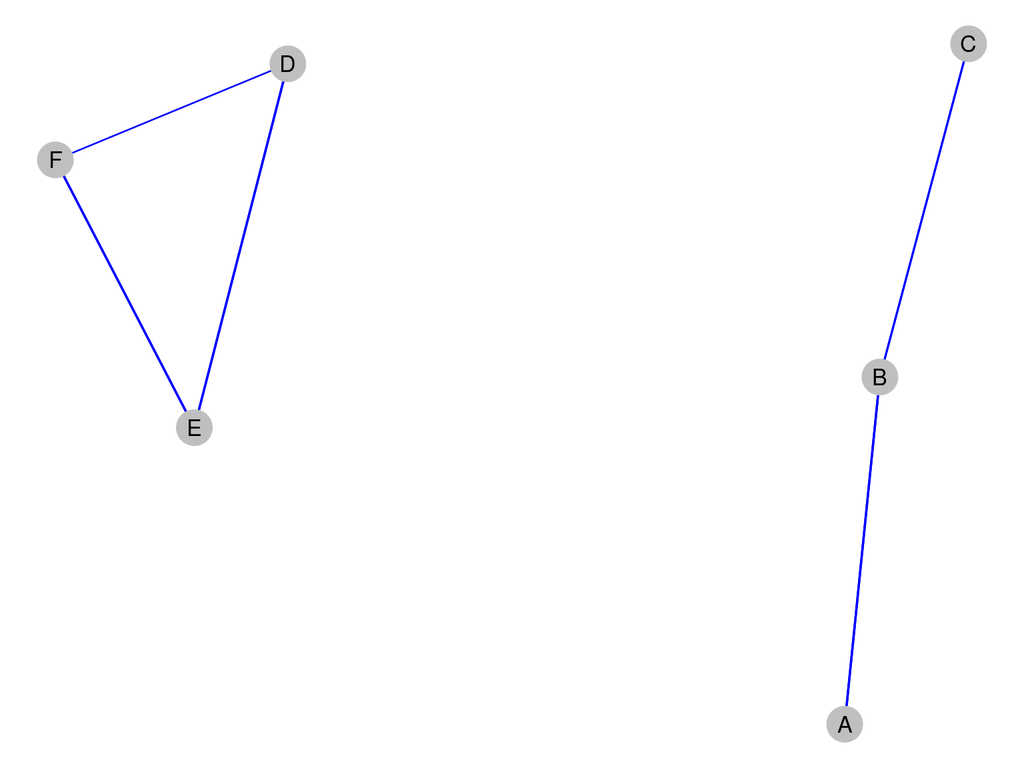

```r
thrs <- 0.35
S_cor_thrs <- S_cor
S_cor_thrs[which(abs(S_cor)<thrs)] = 0

#represent marginal correlation network
diag(S_cor_thrs) = 0
g_cor_thrs <- graph_from_adjacency_matrix(abs(S_cor_thrs),weighted = TRUE)
g_cor_thrs = asNetwork(g_cor_thrs)
ggnet2(g_cor_thrs,label = TRUE,edge.size = "weight",edge.color = "blue")
```

The marginal correlation network is disconnected with this threshold value. What happens if we decrease the threshold ?

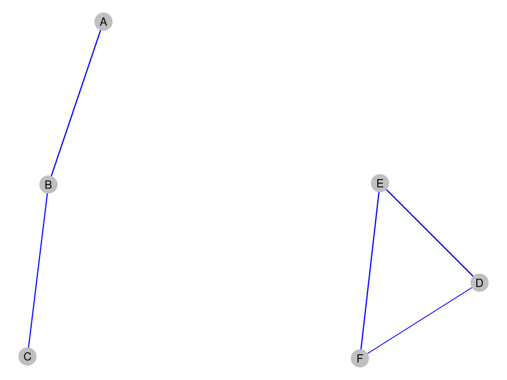

```r
thrs = 0.3
S_cor_thrs <- S_cor
S_cor_thrs[which(abs(S_cor)<thrs)] = 0
diag(S_cor_thrs) = 0
#representing the network with ggnet
g_cor_thrs <- graph_from_adjacency_matrix(abs(S_cor_thrs),weighted = TRUE)
g_cor_thrs = asNetwork(g_cor_thrs)
ggnet2(g_cor_thrs,label = TRUE,edge.size = "weight",edge.color = "blue")
```

Network is still disconnected ! Moreover we have spurious associations. The two highly correlated components have strong marginal correlations inside them.

# Inference with the graphical lasso

We saw that marginal correlations do not recover the original association network. We now aim at recovering the correct partial correlation network using graphical lasso.

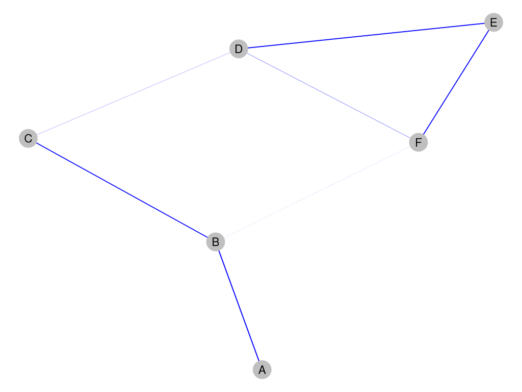

```r
S <- cov(X)
#applying graphical lasso with fixed penalty parameter
mod1 <- glasso(S,rho = 0.05)
pcor_estimated <- - mod1$wi/sqrt(diag(mod1$wi) %*% t(diag(mod1$wi)))
diag(pcor_estimated) = 1
rownames(pcor_estimated) <- colnames(pcor_estimated) <- colnames(S)
#representing the partial correlation network
g_pcor <- graph_from_adjacency_matrix(abs(pcor_estimated),weighted = TRUE)
g_pcor = asNetwork(g_pcor)
ggnet2(g_pcor,label = TRUE,edge.size = "weight",edge.color = "blue")
```

We now run glasso algorithm with a range of penalty parameters to represent coefficient path.

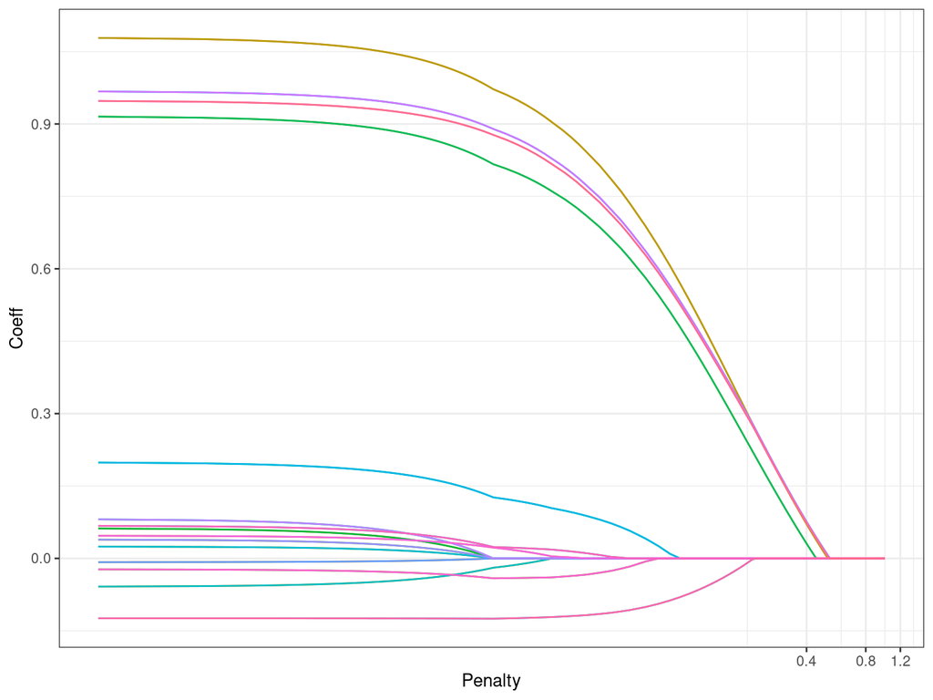

```r
rho_seq <- seq(0.0001,1,length.out = 100)
wi_melted_list <- list()
#for loop over penalty parameters
for(rho in rho_seq){
mod_loc <- glasso(S,rho)
wi_loc <- mod_loc$wi
rownames(wi_loc) <- colnames(wi_loc) <- colnames(S)
#creating data frame for plotting
wi_melted <- melt(wi_loc)
wi_melted <- wi_melted[which(wi_melted[,1] != wi_melted[,2]),]
wi_melted <- cbind(wi_melted,rep(rho,ncol(wi_melted)),paste0(wi_melted[,1],"|",wi_melted[,2]))
colnames(wi_melted) = c("Node1","Node2","Coeff","Penalty","Edge")
wi_melted_list = c(wi_melted_list,list(wi_melted))
}
#merging results
wi_melted_df = do.call(rbind,wi_melted_list)

#representing coefficient path using ggplot2
ggplot(wi_melted_df,aes(x = Penalty, y = Coeff, group = Edge, colour = Edge)) +
  geom_line(show.legend = FALSE) +  coord_trans(x="log10") + theme_bw()
```

Decreasing rho increase the number of non-null coefficients, that is the number of edges of the partial correlation network. How to choose rho ? Several methods, implemented in R, provide automatic selection of penalty parameter. ‘GLASSOO’ package selects the penalty parameter using cross-validation.

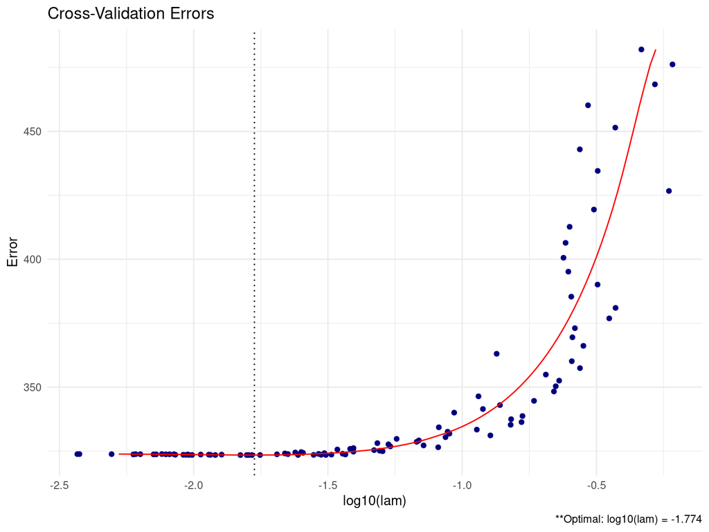

```r
# cross validation for lam
mod2 = GLASSO(X,nlam = 100, trace = "none")
plot(mod2)
```

```r
mod3 = GLASSO(X,lam = exp(-1.773))
mod3$Omega
```

```
##           [,1]      [,2]      [,3]         [,4]      [,5]         [,6]
## [1,] 1.5541584 0.5416053 0.0000000  0.000000000 0.0000000  0.000000000
## [2,] 0.5416053 1.3271850 0.4403733  0.000000000 0.0000000  0.000000000
## [3,] 0.0000000 0.4403733 1.5639287  0.000000000 0.0000000  0.000000000
## [4,] 0.0000000 0.0000000 0.0000000  1.594146899 0.5342061 -0.005093197
## [5,] 0.0000000 0.0000000 0.0000000  0.534206141 1.2978359  0.526863102
## [6,] 0.0000000 0.0000000 0.0000000 -0.005093197 0.5268631  1.593558126
```

# Multivariate Poisson-lognormal model

In this section: - we draw sample in a Poisson-lognormal law - we estimate partial correlations using ‘PLNmodels’ R package - we introduce covariable (abiotic environment) and see how it can introduce confounding effects

```r
p <- 5
n <- 100

g <- igraph::make_star(p,mode = "undirected")
g = igraph::add_edges(g,c(2,3,3,4,4,5,5,2))
V(g)$name <- LETTERS[1:p]
E(g)$weight <- c(2,2,2,2,-0.5,-0.5,-0.5,-0.5)
A <- get.adjacency(g,attr = "weight")
diag(A) = 5
#same mean on each component
mu <- rep(1,p)
Z <- rmvnp(n, mu, Omega = as.matrix(A))
```

We represent the partial correlation network built from the precision matrix.

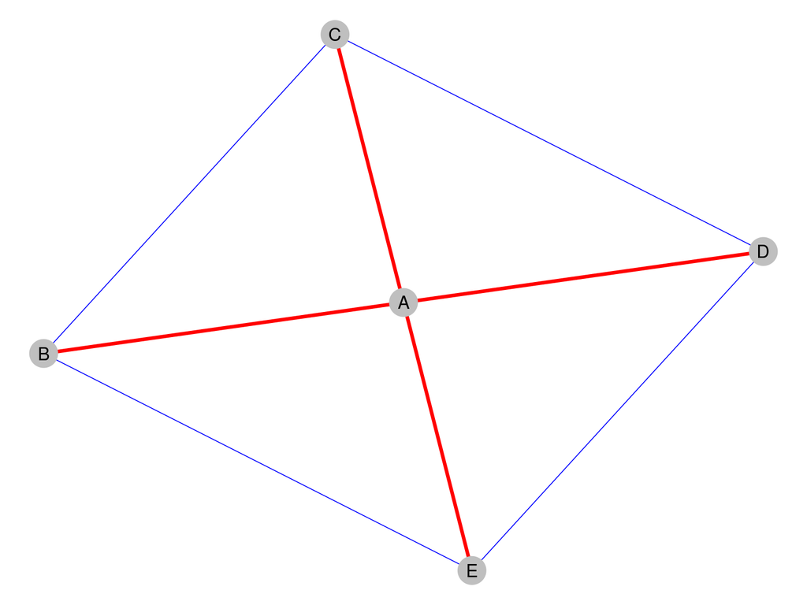

```r
A = as.matrix(A)
p_cor_theo <- - A/(sqrt(diag(A) %*% t(diag(A))))
#removing self-loops
diag(p_cor_theo) = 0
#increasing edge width
p_cor_theo = 3*p_cor_theo
#representing the partial correlation network
g_pcor <- graph_from_adjacency_matrix(abs(p_cor_theo),weighted = TRUE,mode = "undirected")
g_pcor = asNetwork(g_pcor)
ggnet2(g_pcor,label = TRUE,edge.size = "weight",edge.color = c("red","red","red","red","blue","blue","blue","blue"))
```

```r
#sampling in the Poisson
Y <- apply(Z,1:2,function(k) rpois(n = 1,lambda = exp(k)))
rownames(Y) <- paste0("s",1:n)
covariates <- data.frame(env = rep(1,n))
rownames(covariates) <- paste0("s",1:n)

#overdispersion: variance is greater than mean
mean(Y[,1])
```

```
## [1] 4.99
```

```r
var(Y[,1])
```

```
## [1] 59.46455
```

```r
#prepare data for PLNmodels
PLN_data <- prepare_data(Y,covariates)
#similar syntax than R GLM
network_models <- PLNnetwork(Y ~ 1 , data = PLN_data)
```

```
##
##  Initialization...
##  Adjusting 30 PLN with sparse inverse covariance estimation
##  Joint optimization alternating gradient descent and graphical-lasso
##  sparsifying penalty = 1.160399
    sparsifying penalty = 1.071826
    sparsifying penalty = 0.9900148
    sparsifying penalty = 0.9144478
    sparsifying penalty = 0.8446488
    sparsifying penalty = 0.7801775
    sparsifying penalty = 0.7206272
    sparsifying penalty = 0.6656224
    sparsifying penalty = 0.614816
    sparsifying penalty = 0.5678876
    sparsifying penalty = 0.5245412
    sparsifying penalty = 0.4845034
    sparsifying penalty = 0.4475217
    sparsifying penalty = 0.4133628
    sparsifying penalty = 0.3818111
    sparsifying penalty = 0.3526678
    sparsifying penalty = 0.325749
    sparsifying penalty = 0.3008848
    sparsifying penalty = 0.2779186
    sparsifying penalty = 0.2567053
    sparsifying penalty = 0.2371112
    sparsifying penalty = 0.2190127
    sparsifying penalty = 0.2022956
    sparsifying penalty = 0.1868546
    sparsifying penalty = 0.1725921
    sparsifying penalty = 0.1594183
    sparsifying penalty = 0.1472501
    sparsifying penalty = 0.1360106
    sparsifying penalty = 0.125629
    sparsifying penalty = 0.1160399
##  Post-treatments
##  DONE!
```

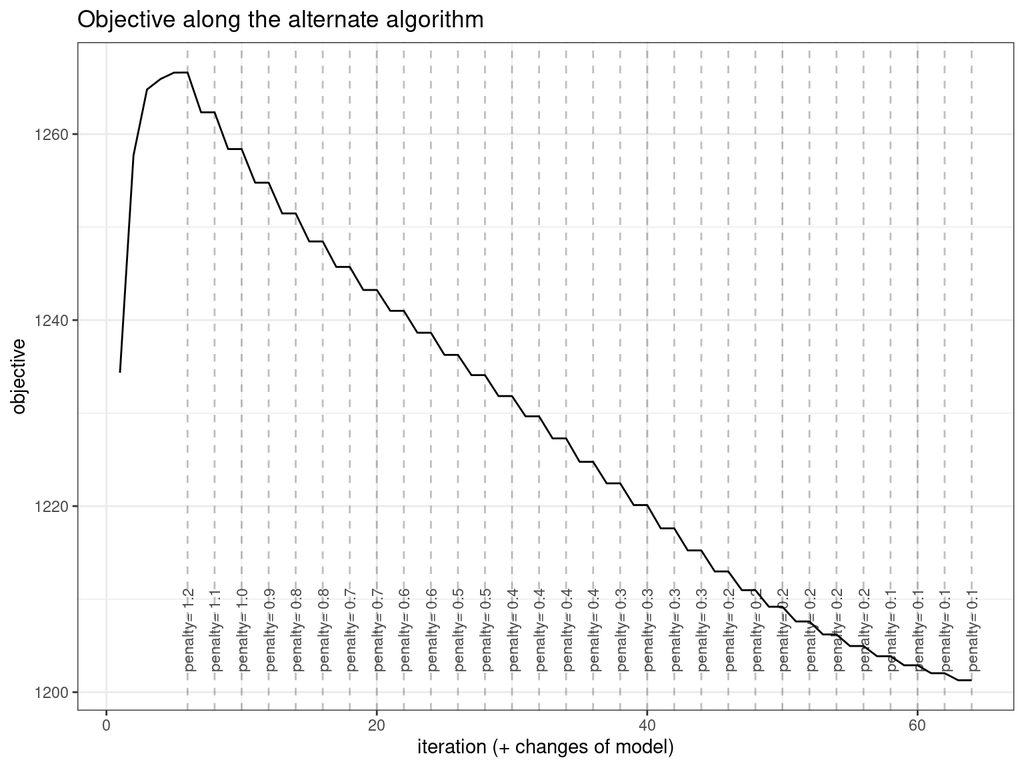

```r
#search for optimal penalty value
plot(network_models, "diagnostic")
```

As for the graphical lasso, we represent the coefficient path along the penalty parameter.

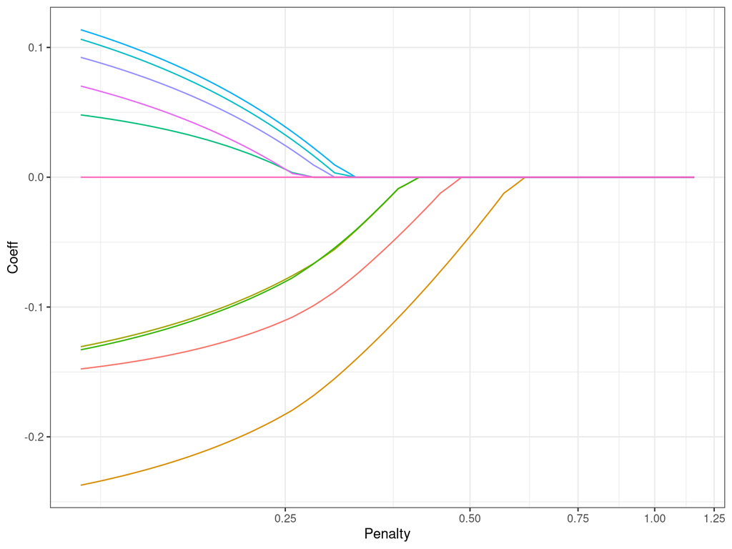

```r
coefficient_path(network_models, corr = TRUE) %>%
  ggplot(aes(x = Penalty, y = Coeff, group = Edge, colour = Edge)) +
  geom_line(show.legend = FALSE) +  coord_trans(x="log10") + theme_bw()
```

**PLNmodels** allows selecting optimal penalty parameter according to an information criterion: the Bayesian Information Criterion (BIC)

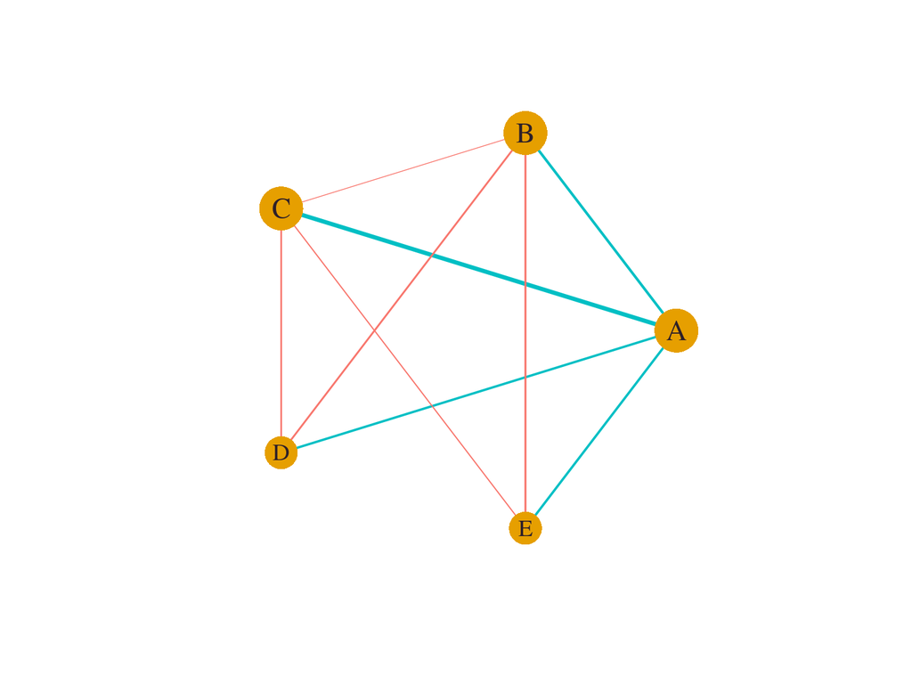

```r
model_BIC <- getBestModel(network_models, "BIC")
#PLNmodels has a method to represent the estimated partial correlation network
model_BIC$plot_network()
```

# Adding covariates in the PLN model

We now introduce a covariable that represents abiotic environment and influences the mean of the normal layer.

```r
## Building mean matrix
#env 1: we assume that A and B are abundant
mu_1 <- c(5,5,1,1,1)
#env 1: we assume that C, D and E are abundant
mu_2 <- c(1,1,5,5,5)

#sampling Z values in env1 and env2
Z1 <- rmvnp(n/2, mu_1, Omega = as.matrix(A))
Z2 <- rmvnp(n/2, mu_2, Omega = as.matrix(A))
Z <- rbind(Z1,Z2)
```

```r
Y <- apply(Z,1:2,function(k) rpois(n = 1,lambda = exp(k)))
PLN_data <- prepare_data(Y,covariates)
```

We now estimate a PLN model without taking into account the covariable.

```r
#build the network model
network_models <- PLNnetwork(Y ~ 1 , data = as.data.frame(cbind(Y,covariates)))
```

```
##
##  Initialization...
##  Adjusting 30 PLN with sparse inverse covariance estimation
##  Joint optimization alternating gradient descent and graphical-lasso
##  sparsifying penalty = 4.725373
    sparsifying penalty = 4.364689
    sparsifying penalty = 4.031536
    sparsifying penalty = 3.723812
    sparsifying penalty = 3.439577
    sparsifying penalty = 3.177037
    sparsifying penalty = 2.934537
    sparsifying penalty = 2.710546
    sparsifying penalty = 2.503652
    sparsifying penalty = 2.312551
    sparsifying penalty = 2.136036
    sparsifying penalty = 1.972994
    sparsifying penalty = 1.822397
    sparsifying penalty = 1.683295
    sparsifying penalty = 1.55481
    sparsifying penalty = 1.436133
    sparsifying penalty = 1.326514
    sparsifying penalty = 1.225263
    sparsifying penalty = 1.131739
    sparsifying penalty = 1.045355
    sparsifying penalty = 0.9655636
    sparsifying penalty = 0.891863
    sparsifying penalty = 0.8237878
    sparsifying penalty = 0.7609088
    sparsifying penalty = 0.7028293
    sparsifying penalty = 0.6491829
    sparsifying penalty = 0.5996314
    sparsifying penalty = 0.553862
    sparsifying penalty = 0.5115862
    sparsifying penalty = 0.4725373
##  Post-treatments
##  DONE!
```

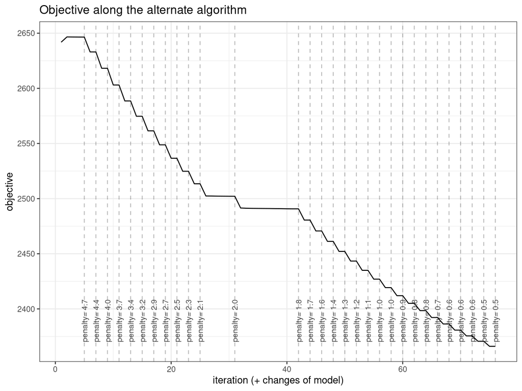

```r
plot(network_models, "diagnostic")
```

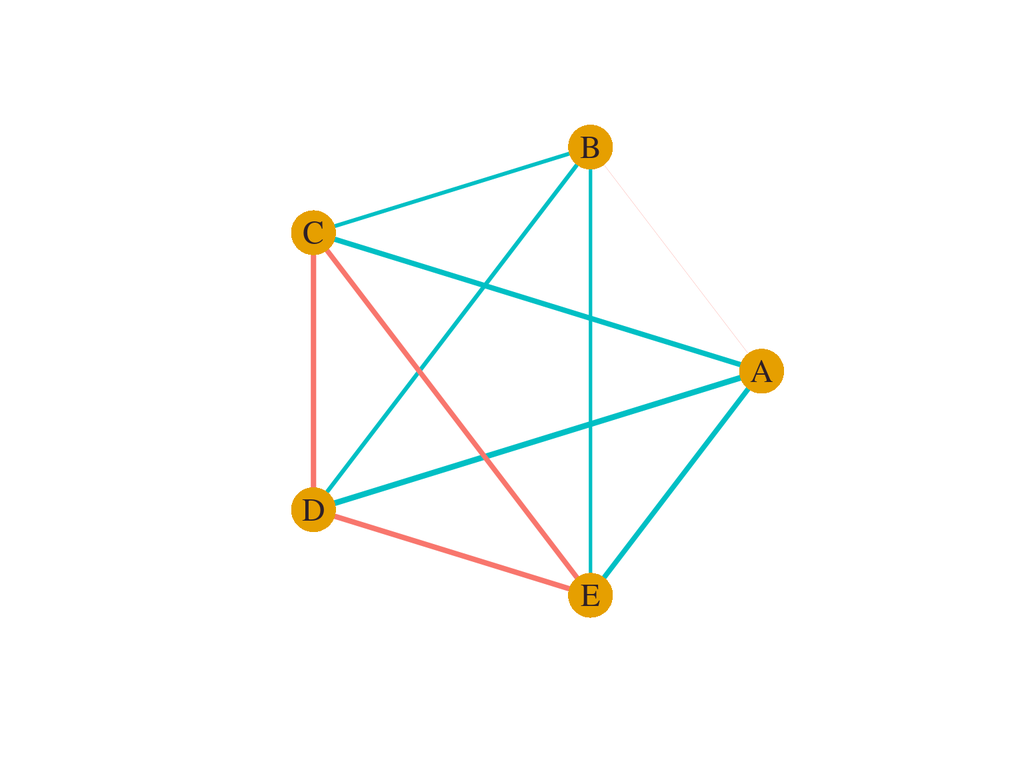

```r
model_BIC <- getBestModel(network_models, "BIC")
model_BIC$plot_network()
```

We detect a spurious positive association between C, D and E. This is due to the fact that C, D and E are abundant in env2. Similarly, we detect a spurious positive association between A and B. We now estimate a PLN model again but we take into account the covariable to hopefully remove spurious associations.

```r
# Adding covariates
covariates <- data.frame(env = c(rep(1,n/2),rep(2,n/2)))

network_models <- PLNnetwork(Y ~ env , data = as.data.frame(cbind(Y,covariates)))
```

```
##
##  Initialization...
##  Adjusting 30 PLN with sparse inverse covariance estimation
##  Joint optimization alternating gradient descent and graphical-lasso
##  sparsifying penalty = 0.9875057
    sparsifying penalty = 0.9121302
    sparsifying penalty = 0.8425081
    sparsifying penalty = 0.7782002
    sparsifying penalty = 0.7188008
    sparsifying penalty = 0.6639354
    sparsifying penalty = 0.6132577
    sparsifying penalty = 0.5664483
    sparsifying penalty = 0.5232118
    sparsifying penalty = 0.4832755
    sparsifying penalty = 0.4463875
    sparsifying penalty = 0.4123151
    sparsifying penalty = 0.3808434
    sparsifying penalty = 0.351774
    sparsifying penalty = 0.3249234
    sparsifying penalty = 0.3001223
    sparsifying penalty = 0.2772142
    sparsifying penalty = 0.2560547
    sparsifying penalty = 0.2365102
    sparsifying penalty = 0.2184576
    sparsifying penalty = 0.2017829
    sparsifying penalty = 0.186381
    sparsifying penalty = 0.1721547
    sparsifying penalty = 0.1590143
    sparsifying penalty = 0.1468769
    sparsifying penalty = 0.1356659
    sparsifying penalty = 0.1253106
    sparsifying penalty = 0.1157458
    sparsifying penalty = 0.106911
    sparsifying penalty = 0.09875057
##  Post-treatments
##  DONE!
```

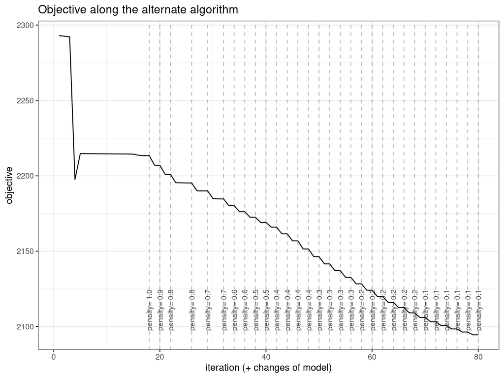

```r
plot(network_models, "diagnostic")
```

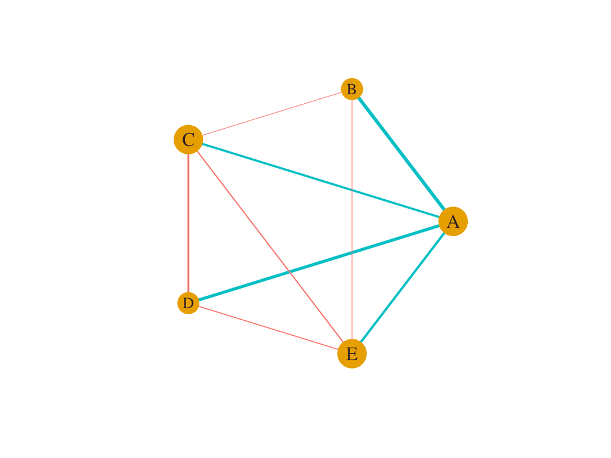

```r
model_BIC <- getBestModel(network_models, "BIC")
model_BIC$plot_network()
```